# One-way and two-way analysis of variance

Ein ausführliches Beispiel

JJ Allaire and Yihui Xie

2018-06-30

# Einführung

```r
library(tidyverse)
library(car)
library(emmeans)
library(sjstats)
afex::set_sum_contrasts()
```

Beginnen wir mit einem einfachen Beispiel. Unser Datensatz beschäftigt sich mit der Ernährung von Menschen.

```r
diet <- read_csv("diet.csv")
glimpse(diet)
```

```
## Observations: 78
## Variables: 7
## $ Person       <int> 25, 26, 1, 2, 3, 4, 5, 6, 7, 8, 9, 10, 11, 12, 13...
## $ gender       <int> NA, NA, 0, 0, 0, 0, 0, 0, 0, 0, 0, 0, 0, 0, 0, 0,...
## $ Age          <int> 41, 32, 22, 46, 55, 33, 50, 50, 37, 28, 28, 45, 6...
## $ Height       <int> 171, 174, 159, 192, 170, 171, 170, 201, 174, 176,...
## $ pre.weight   <int> 60, 103, 58, 60, 64, 64, 65, 66, 67, 69, 70, 70, ...
## $ Diet         <int> 2, 2, 1, 1, 1, 1, 1, 1, 1, 1, 1, 1, 1, 1, 1, 1, 2...
## $ weight6weeks <dbl> 60.0, 103.0, 54.2, 54.0, 63.3, 61.1, 62.2, 64.0, ...
```

Die Variable `weight6weeks` gibt an, wie viel jemand nach 6 Wochen Diät gewogen hat. Der erste Gewichtswert steckt in der Variable `pre.weight`. Wir wollen testen, inwieweit sich die verschiedenen Diäten auf das Gewicht ausgewirkt haben. Dazu müssen wir die Gewichtsdifferenz berechnen:

```r
diet <- diet %>%
  mutate(
    diff = weight6weeks - pre.weight,
    Diet = factor(Diet)
  )
```

Die Variable gibt nun an, ob jemand zu- oder abgenommen hat. Ein positiver Wert bedeutet, dass jemand zugenommen hat. Ein negativer Wert bedeutet, dass jemand abgenommen hat.

# One-Way Anova - Einfaktorielle Varianzanalyse

## EDA Faktor

Wir möchten nun heraus finden, ob die Diät ein signifikanter Prädiktor des Gewichts ist. Schauen wir uns zunächst die Gewichtsunterschiede mit Boxplots an:

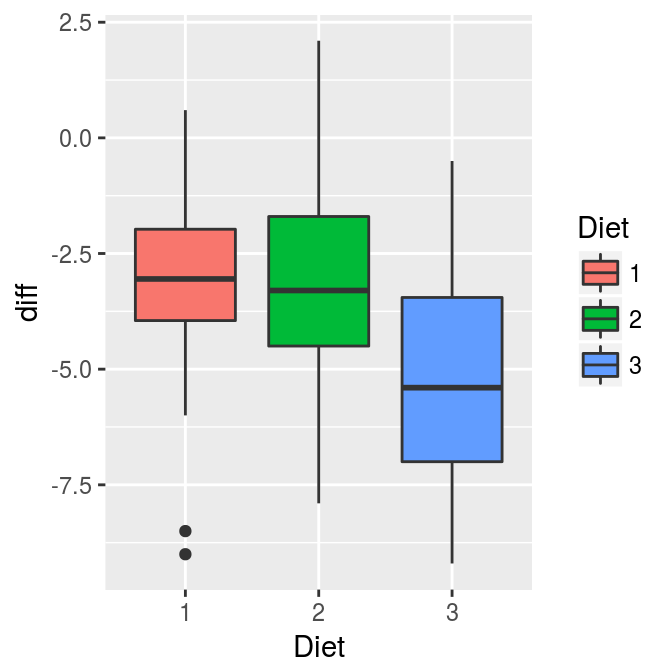

Boxplot mit Ausreißern.

```r
ggplot(diet, aes(Diet, diff, group = Diet)) +
  geom_boxplot(aes(fill = Diet))
```

Es gibt zwei Ausreißer in der ersten Gruppe. Nehmen wir diese Ausreißer heraus.

```r
diet_no_outlier <- diet %>%
  filter(!(Diet == "1" & diff < -7.5))
```

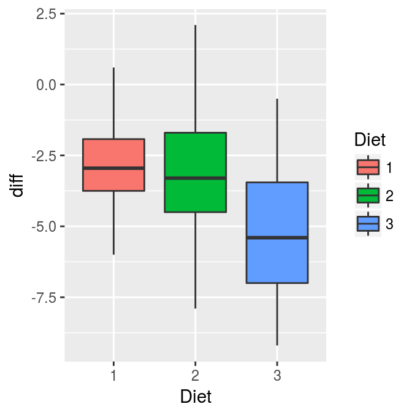

Boxplot ohne Ausreißer

```r
ggplot(diet_no_outlier, aes(Diet, diff, group = Diet)) +
  geom_boxplot(aes(fill = Diet))
```

Jetzt haben wir eine bessere Repräsentation der Daten.

## Assumptions

Bevor wir etwas Rechnen, sollten wir die Annahmen prüfen.

Mehr Informationen [hier](https://statistics.laerd.com/spss-tutorials/one-way-anova-using-spss-statistics.php)

### Normalverteilung der abhängigen Variable

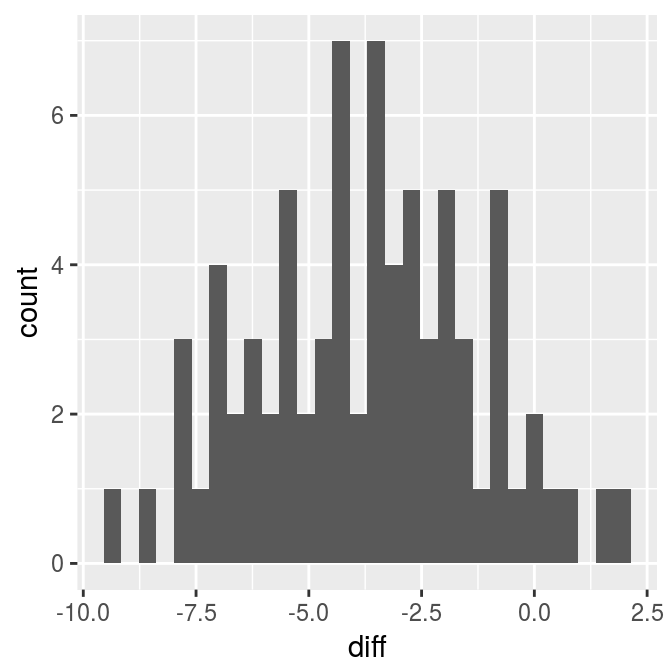

Histogram abhängige Variable

```r
ggplot(diet_no_outlier, aes(x = diff)) +
  geom_histogram()
```

Sieht gut aus.

### Homogeneity of variance

Die Varianzen der unterschiedlichen Gruppen sollten ähnlich sein. Am einfachsten kann man das mit dem Levene-Test testen:

```r
leveneTest(diff ~ Diet, data = diet_no_outlier)
```

```
## Levene's Test for Homogeneity of Variance (center = median)
##       Df F value Pr(>F)
## group  2  2.7961 0.0676 .
##       73
## ---
## Signif. codes:  0 '***' 0.001 '**' 0.01 '*' 0.05 '.' 0.1 ' ' 1
```

Die Varianzen sind unterschiedlich, aber eben nicht signifikant. Wir können daher mit Vorsicht die Annahme der Varianzhomogenität zwischen den Gruppen annehmen.

## Regressionsmodel

Später möchten wir Kontraste rechnen, da Annahmen über die Effektivität der Diäten haben. Wir glauben, dass Diät 1 > Diät 2 > Diät 3. Wir testen daher Diät 1 gegen Diät 2 und Diät 2 gegen Diät 3.

```r
contrasts(diet_no_outlier$Diet)
```

```
##   [,1] [,2]
## 1    1    0
## 2    0    1
## 3   -1   -1
```

Monentan wird Gruppe 1 mit Gruppe 3 und Gruppe 2 mit Gruppe 3 verglichen. Ändern wir das.

```r
contrasts(diet_no_outlier$Diet) <-
  cbind(c(1, -1, 0), c(0, 1, -1))
contrasts(diet_no_outlier$Diet)
```

```
##   [,1] [,2]
## 1    1    0
## 2   -1    1
## 3    0   -1
```

Voilà. Unser Faktor hat die richtigen Kontraste. Nun können wir unser Modell bauen:

```r
(model <- lm(diff ~ Diet, data = diet_no_outlier,
             contrasts = list(Diet = contrasts(diet_no_outlier$Diet))))
```

```
##
## Call:
## lm(formula = diff ~ Diet, data = diet_no_outlier, contrasts = list(Diet = contrasts(diet_no_outlier$Diet)))
##
## Coefficients:
## (Intercept)        Diet1        Diet2
##      -3.660        0.855        1.489
```

Um heraus zu finden, ob es signifikante Unterschiede zwischen den Gruppen gibt, müssen wir die `Anova` Funktion über das Modell laufen lassen:

```r
model %>% Anova(., type = 3)
```

```
## Anova Table (Type III tests)
##
## Response: diff
##              Sum Sq Df  F value    Pr(>F)
## (Intercept) 1008.38  1 201.5383 < 2.2e-16 ***
## Diet          86.51  2   8.6453 0.0004269 ***
## Residuals    365.25 73
## ---
## Signif. codes:  0 '***' 0.001 '**' 0.01 '*' 0.05 '.' 0.1 ' ' 1
```

Die Ergebnisse sind hochsignifikant. Die Diät hat anscheinend einen Einfluss auf die Gewichtszu- oder abnahme. Mal sehen, welche der Kontraste signifikant ist:

```r
model %>% summary.aov(split = list(
  Diet = list("1 vs. 2" = 1,
              "2 vs. 3" = 2)
  ))
```

```
##                 Df Sum Sq Mean Sq F value   Pr(>F)
## Diet             2   86.5   43.26   8.645 0.000427 ***
##   Diet: 1 vs. 2  1    0.0    0.04   0.008 0.927692
##   Diet: 2 vs. 3  1   86.5   86.47  17.282 8.67e-05 ***
## Residuals       73  365.2    5.00
## ---
## Signif. codes:  0 '***' 0.001 '**' 0.01 '*' 0.05 '.' 0.1 ' ' 1
```

Der Unterschied zwischen Diät 1 und Diät 2 ist nicht signifikant. Der Unterschied zwischen Diät 2 und Diät 3 ist signifikant.

```r
model %>% emmeans("Diet") %>%
  pairs
```

```
##  contrast  estimate        SE df t.ratio p.value
##  1 - 2    0.2213805 0.6424477 73   0.345  0.9367
##  1 - 3    2.3436027 0.6424477 73   3.648  0.0014
##  2 - 3    2.1222222 0.6087880 73   3.486  0.0024
##
## P value adjustment: tukey method for comparing a family of 3 estimates
```

Die Werte passen nun gut zusammen. Zum Schlüss müssen wir sehen, wie groß die Effekte sind:

```r
eta_sq(model)
```

```
## # A tibble: 1 x 2
##   term  etasq
##   <chr> <dbl>
## 1 Diet  0.192
```